# Week 6

C.A. Kiahtipes, G. Herbert

2023-10-12

## Week 6: Differences in Populations

This week we are going to use what we have learned about frequency distributions and apply this to assess differences in two sets of sample populations.

### 1 Analysis of Variance and Linear Regression

We are adding a layer of complexity to our fake core data. Read the “Fake_core_plus.csv” file and let’s see what this additional bit of data looks like.

```r
fake_core = read.csv("data/Fake_core_plus.csv", header = TRUE, row.names = "depth")

fake_core$stratum
```

```
##   [1] "A" "A" "A" "A" "A" "A" "A" "A" "A" "B" "B" "B" "B" "B" "B" "B" "B" "B"
##  [19] "B" "B" "B" "B" "B" "C" "C" "C" "C" "C" "C" "C" "C" "C" "C" "C" "D" "D"
##  [37] "D" "D" "D" "D" "D" "D" "D" "D" "D" "D" "D" "E" "E" "E" "E" "E" "E" "E"
##  [55] "E" "E" "E" "E" "E" "E" "E" "E" "E" "E" "E" "E" "E" "F" "F" "F" "F" "F"
##  [73] "F" "F" "F" "F" "F" "F" "F" "F" "F" "F" "F" "F" "G" "G" "G" "G" "G" "G"
##  [91] "G" "G" "G" "G" "G" "G" "G" "G" "G" "G"
```

As a reminder, we can check out data with head() or tail() also and see how the new information lies in the table.

```r
head(fake_core)
```

```
##     Cyperaceae.undiff. Typha Poaceae Alchornea Macaranga Celtis Blighia
## -2                  10     3      50        10         3     28      16
## -4                  11     3      46        25        16     33      14
## -6                   6     3      35        35        26     16      16
## -8                  19     3      42         3        43     17      19
## -10                  9     2      57        38        12     24      18
## -12                 15     3      69        18        34     24      19
##     Sapotaceae.undiff. Guibourtia.demeusei stratum
## -2                  25                  25       A
## -4                  25                  28       A
## -6                  13                  26       A
## -8                   9                  24       A
## -10                 22                  26       A
## -12                 21                  23       A
```

```r
tail(fake_core)
```

```
##      Cyperaceae.undiff. Typha Poaceae Alchornea Macaranga Celtis Blighia
## -190                 36     9      43        79        73     24      10
## -192                 34    10      23        47        82     34       7
## -194                 41    11      20        64        41     31       4
## -196                 37    11      12        86        36     27       7
## -198                 40    10      25        71        44     31       4
## -200                 30    12      14        66        43     31       3
##      Sapotaceae.undiff. Guibourtia.demeusei stratum
## -190                 17                   9       G
## -192                  7                   6       G
## -194                  4                   7       G
## -196                 14                   5       G
## -198                  8                   4       G
## -200                 17                   2       G
```

In this imaginary setting, let us assign stratum D to one of the major sample groups. Does it belong with A, B, and C or with E, F, and G?

```r
upper_cyp = fake_core$Cyperaceae.undiff.[fake_core$stratum == "A" |
                                           fake_core$stratum == "B" |
                                           fake_core$stratum == "C"]


lower_cyp = fake_core$Cyperaceae.undiff.[fake_core$stratum == "E" |
                                           fake_core$stratum == "F" |
                                           fake_core$stratum == "G"]

upper_sap = fake_core$Sapotaceae.undiff.[fake_core$stratum == "A" |
                                           fake_core$stratum == "B" |
                                           fake_core$stratum == "C"]

lower_sap = fake_core$Sapotaceae.undiff.[fake_core$stratum == "E" |
                                           fake_core$stratum == "F" |
                                           fake_core$stratum == "G"]
```

Let’s compare the distribution of data between the upper, lower, and stratum “D”.

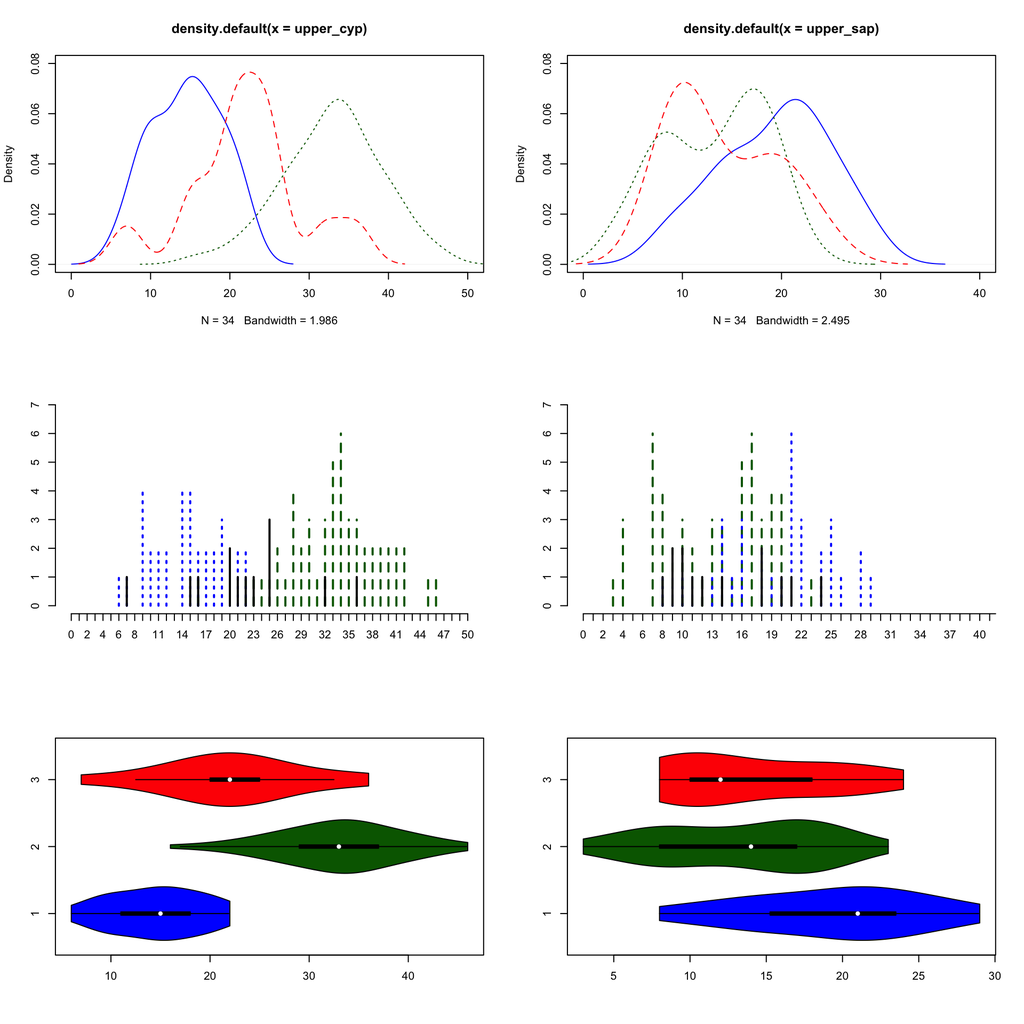

```r
par(mfrow = c(3, 2))

plot(density(upper_cyp), xlim = c(0,50), ylim = c(0, 0.08), col = "blue")
lines(density(lower_cyp), lty = 3, col = "darkgreen")
lines(density(fake_core$Cyperaceae.undiff.[fake_core$stratum == "D"]), lty = 2, col = "red")

plot(density(upper_sap), xlim = c(0,40), ylim = c(0, 0.08), col = "blue")
lines(density(lower_sap), lty = 3, col = "darkgreen")
lines(density(fake_core$Sapotaceae.undiff.[fake_core$stratum == "D"]), lty =2, col = "red")

plot(0, 0, pch = NA, axes = FALSE, ann = FALSE, xlim = c(0, 50), ylim = c(0, 7))
lines(table(lower_cyp), lty = 2, col = "darkgreen")
lines(table(upper_cyp), lty = 3, col = "blue")
lines(table(fake_core$Cyperaceae.undiff.[fake_core$stratum == "D"]), lty = 1)
axis(1, at = 0:50)
axis(2, at = 0:7)

plot(0, 0, pch = NA, axes = FALSE, ann = FALSE, xlim = c(0, 40), ylim = c(0, 7))
lines(table(lower_sap), lty = 2, col = "darkgreen")
lines(table(upper_sap), lty = 3, col = "blue")
lines(table(fake_core$Sapotaceae.undiff.[fake_core$stratum == "D"]), lty = 1)
axis(1, at = 0:50)
axis(2, at = 0:7)

vioplot::vioplot(upper_cyp, lower_cyp, fake_core$Cyperaceae.undiff.[fake_core$stratum == "D"],
                 horizontal = TRUE,
                 col = c("blue", "darkgreen", "red"))

vioplot::vioplot(upper_sap, lower_sap, fake_core$Sapotaceae.undiff.[fake_core$stratum == "D"],
                 horizontal = TRUE,
                 col = c("blue", "darkgreen", "red"))
```

```r
par(mfrow = c(1,1))
```

We see that our Cyperaceae undiff. groups are relatively well separated, while the Sapotaceae undiff. groups have a lot more overlap. But how different? We need some ways to quantify the differences between these distributions. Enter the Analysis of Variance, or ANOVA. The aov() function runs the ANOVA test, which compares means and dispersion. First, we will simplify the stratigraphic categories so that we can ask our question: is D more likely to be a part of the same population as A, B, and C, or E, F, and G?

```r
all_strat = fake_core$stratum

fake_core = fake_core[,-c(ncol(fake_core))] #Here we purge the stratum column so we have a numeric matrix.

smp_strat <- vector("character", length = nrow(fake_core))

smp_strat[all_strat == "A" | all_strat == "B" | all_strat == "C"] = "Upper"

smp_strat[all_strat == "E" | all_strat == "F" | all_strat == "G"] = "Lower"

smp_strat[all_strat == "D"] = "Test"

smp_strat
```

```
##   [1] "Upper" "Upper" "Upper" "Upper" "Upper" "Upper" "Upper" "Upper" "Upper"
##  [10] "Upper" "Upper" "Upper" "Upper" "Upper" "Upper" "Upper" "Upper" "Upper"
##  [19] "Upper" "Upper" "Upper" "Upper" "Upper" "Upper" "Upper" "Upper" "Upper"
##  [28] "Upper" "Upper" "Upper" "Upper" "Upper" "Upper" "Upper" "Test"  "Test"
##  [37] "Test"  "Test"  "Test"  "Test"  "Test"  "Test"  "Test"  "Test"  "Test"
##  [46] "Test"  "Test"  "Lower" "Lower" "Lower" "Lower" "Lower" "Lower" "Lower"
##  [55] "Lower" "Lower" "Lower" "Lower" "Lower" "Lower" "Lower" "Lower" "Lower"
##  [64] "Lower" "Lower" "Lower" "Lower" "Lower" "Lower" "Lower" "Lower" "Lower"
##  [73] "Lower" "Lower" "Lower" "Lower" "Lower" "Lower" "Lower" "Lower" "Lower"
##  [82] "Lower" "Lower" "Lower" "Lower" "Lower" "Lower" "Lower" "Lower" "Lower"
##  [91] "Lower" "Lower" "Lower" "Lower" "Lower" "Lower" "Lower" "Lower" "Lower"
## [100] "Lower"
```

Our basic hypothesis here is that D is part of the Upper group and not the Lower group. We could just ask ourselves, what are the chances that the sample mean of D comes from the same population with the sample mean of the Upper group or Lower group?

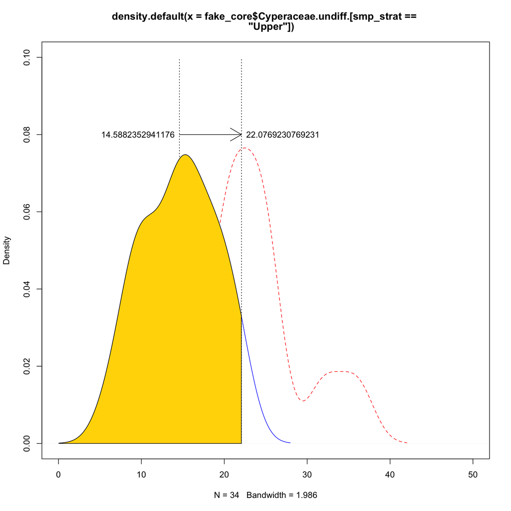

```r
plot(density(fake_core$Cyperaceae.undiff.[smp_strat == "Upper"]), xlim = c(0,50), ylim = c(0, 0.10), col = "blue")
lines(density(fake_core$Cyperaceae.undiff.[smp_strat == "Test"]), lty = 2, col = "red")

lines(c(rep(mean(fake_core$Cyperaceae.undiff.[smp_strat == "Upper"]), 2)),
      c(0,0.10),
      lty = 3)

text(mean(fake_core$Cyperaceae.undiff.[smp_strat == "Test"])+5, 0.08, labels = paste0(mean(fake_core$Cyperaceae.undiff.[smp_strat == "Test"])))

lines(c(rep(mean(fake_core$Cyperaceae.undiff.[smp_strat == "Test"]), 2)),
      c(0,0.10),
      lty = 3)

text(mean(fake_core$Cyperaceae.undiff.[smp_strat == "Upper"])-5, 0.08, labels = paste0(mean(fake_core$Cyperaceae.undiff.[smp_strat == "Upper"])))

arrows(mean(fake_core$Cyperaceae.undiff.[smp_strat == "Upper"]), 0.08, mean(fake_core$Cyperaceae.undiff.[smp_strat == "Test"]), 0.08)

#Use custom function from last week.

norm_area = function(dist, value, col = "gray"){
  yt = dist$y[dist$x < value]
  yb = rep(0, length(yt))

  x = dist$x[dist$x < value]


  polygon(c(x, rev(x)), c(yt,yb), col = col)
}

norm_area(density(fake_core$Cyperaceae.undiff.[smp_strat == "Upper"]), mean(fake_core$Cyperaceae.undiff.[smp_strat == "Test"]), col = "gold")
```

Basic ANOVA call. The aov() function expects a “model” as input. It wants some group of numeric data and a set of categorical assignments by which to compare it.

```r
aov(fake_core$Cyperaceae.undiff.~smp_strat)
```

```
## Call:
##    aov(formula = fake_core$Cyperaceae.undiff. ~ smp_strat)
##
## Terms:
##                 smp_strat Residuals
## Sum of Squares   7086.761  3324.479
## Deg. of Freedom         2        97
##
## Residual standard error: 5.854313
## Estimated effects may be unbalanced
```

This is the basic result, but we don’t get many details. Let’s make an object (many coders use “.” when making object names with output) and fill it with the result. We will also do this by the pairs we are comparing (D and Upper, D and Lower). Notice we’re subsetting the data.

```r
upper.model <- aov(fake_core$Cyperaceae.undiff.[smp_strat == "Test" | smp_strat == "Upper"]~smp_strat[smp_strat == "Test" | smp_strat == "Upper"])

lower.model <- aov(fake_core$Cyperaceae.undiff.[smp_strat == "Test" | smp_strat == "Lower"]~smp_strat[smp_strat == "Test" | smp_strat == "Lower"])
```

Look at the results by summarizing the object.

```r
summary(upper.model)
```

```
##                                                       Df Sum Sq Mean Sq F value
## smp_strat[smp_strat == "Test" | smp_strat == "Upper"]  1  527.4   527.4   18.24
## Residuals                                             45 1301.2    28.9
##                                                         Pr(>F)
## smp_strat[smp_strat == "Test" | smp_strat == "Upper"] 9.94e-05 ***
## Residuals
## ---
## Signif. codes:  0 '***' 0.001 '**' 0.01 '*' 0.05 '.' 0.1 ' ' 1
```

```r
summary(lower.model)
```

```
##                                                       Df Sum Sq Mean Sq F value
## smp_strat[smp_strat == "Test" | smp_strat == "Lower"]  1   1220  1219.9   29.28
## Residuals                                             64   2666    41.7
##                                                         Pr(>F)
## smp_strat[smp_strat == "Test" | smp_strat == "Lower"] 9.99e-07 ***
## Residuals
## ---
## Signif. codes:  0 '***' 0.001 '**' 0.01 '*' 0.05 '.' 0.1 ' ' 1
```

### 2 AOV with Percent Transformed Data

Raw counts may not be the best way to assess the differences in the original past population, so we control for uneven sample sizes by transforming into percents.

```r
fake_pct <- (fake_core[,1:ncol(fake_core)-1] #Take fake_core object, including all rows except the last one (derived by ncol())
             /apply(fake_core[,1:ncol(fake_core)-1],1,sum))*100 #Divide those by the row sums of the same object columns (also derived by ncol())

head(fake_pct)
```

```
##     Cyperaceae.undiff.    Typha  Poaceae Alchornea Macaranga   Celtis   Blighia
## -2            6.896552 2.068966 34.48276  6.896552  2.068966 19.31034 11.034483
## -4            6.358382 1.734104 26.58960 14.450867  9.248555 19.07514  8.092486
## -6            4.000000 2.000000 23.33333 23.333333 17.333333 10.66667 10.666667
## -8           12.258065 1.935484 27.09677  1.935484 27.741935 10.96774 12.258065
## -10           4.945055 1.098901 31.31868 20.879121  6.593407 13.18681  9.890110
## -12           7.389163 1.477833 33.99015  8.866995 16.748768 11.82266  9.359606
##     Sapotaceae.undiff.
## -2           17.241379
## -4           14.450867
## -6            8.666667
## -8            5.806452
## -10          12.087912
## -12          10.344828
```

```r
tail(fake_pct)
```

```
##      Cyperaceae.undiff.    Typha   Poaceae Alchornea Macaranga    Celtis
## -190           12.37113 3.092784 14.776632  27.14777  25.08591  8.247423
## -192           13.93443 4.098361  9.426230  19.26230  33.60656 13.934426
## -194           18.98148 5.092593  9.259259  29.62963  18.98148 14.351852
## -196           16.08696 4.782609  5.217391  37.39130  15.65217 11.739130
## -198           17.16738 4.291845 10.729614  30.47210  18.88412 13.304721
## -200           13.88889 5.555556  6.481481  30.55556  19.90741 14.351852
##       Blighia Sapotaceae.undiff.
## -190 3.436426           5.841924
## -192 2.868852           2.868852
## -194 1.851852           1.851852
## -196 3.043478           6.086957
## -198 1.716738           3.433476
## -200 1.388889           7.870370
```

Notice that we’ve excluded the stratigraphic details, so we will call them from the all_strat object when we need them.

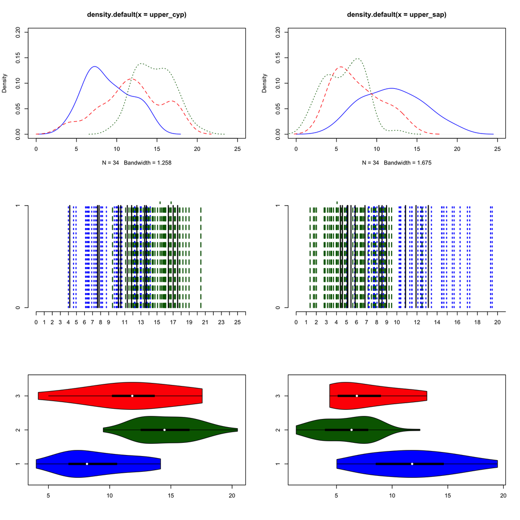

```r
upper_cyp = fake_pct$Cyperaceae.undiff.[all_strat == "A" |
                                           all_strat == "B" |
                                           all_strat == "C"]


lower_cyp = fake_pct$Cyperaceae.undiff.[all_strat == "E" |
                                           all_strat == "F" |
                                           all_strat == "G"]

upper_sap = fake_pct$Sapotaceae.undiff.[all_strat == "A" |
                                           all_strat == "B" |
                                           all_strat == "C"]

lower_sap = fake_pct$Sapotaceae.undiff.[all_strat == "E" |
                                           all_strat == "F" |
                                           all_strat == "G"]

#Three plots showing different ways to assess differences in distributions.

par(mfrow = c(3, 2))

plot(density(upper_cyp), xlim = c(0,25), ylim = c(0, 0.20), col = "blue")
lines(density(lower_cyp), lty = 3, col = "darkgreen")
lines(density(fake_pct$Cyperaceae.undiff.[all_strat == "D"]), lty = 2, col = "red")

plot(density(upper_sap), xlim = c(0,25), ylim = c(0, 0.20), col = "blue")
lines(density(lower_sap), lty = 3, col = "darkgreen")
lines(density(fake_pct$Sapotaceae.undiff.[all_strat == "D"]), lty =2, col = "red")

plot(0, 0, pch = NA, axes = FALSE, ann = FALSE, xlim = c(0, 25), ylim = c(0, 1))
lines(table(lower_cyp), lty = 2, col = "darkgreen")
lines(table(upper_cyp), lty = 3, col = "blue")
lines(table(fake_pct$Cyperaceae.undiff.[all_strat == "D"]), lty = 1)
axis(1, at = 0:50)
axis(2, at = 0:1)

plot(0, 0, pch = NA, axes = FALSE, ann = FALSE, xlim = c(0, 20), ylim = c(0, 1))
lines(table(lower_sap), lty = 2, col = "darkgreen")
lines(table(upper_sap), lty = 3, col = "blue")
lines(table(fake_pct$Sapotaceae.undiff.[all_strat == "D"]), lty = 1)
axis(1, at = 0:50)
axis(2, at = 0:1)

vioplot::vioplot(upper_cyp, lower_cyp, fake_pct$Cyperaceae.undiff.[all_strat == "D"],
                 horizontal = TRUE,
                 col = c("blue", "darkgreen", "red"))

vioplot::vioplot(upper_sap, lower_sap, fake_pct$Sapotaceae.undiff.[all_strat == "D"],
                 horizontal = TRUE,
                 col = c("blue", "darkgreen", "red"))
```

```r
par(mfrow = c(1,1))
```